# Project 2

## Rainfall

First, add a continent and delete the extra lines

```r
#note - this first column imports into R as X....City,
#however, the html would not render.
#so I rendered a glimpse of this table in a separate file, and it's just "City"
#I've changed the code below so it renders properly
#however, for this to run locally, it may need to be changed
#code is provided below

rainfall2 <- rainfall |>
  select(City:Dec) |>
  mutate(continent = "") |>
  rename(city = City, country = Country, yearly = Year)


#If the above code does not run, please use this
#(with the corrected first column name)
#rainfall2 <- rainfall |>
#  select(X...City:Dec) |>
#  mutate(continent = "") |>
#  rename(city = X...City, country = Country, yearly = Year)

#1-37 is Africa, 92 - 129 is Asia, 131 - 270 is Europe, 272 - 305 is North America, 311 - 362 is Oceania, 365 - 535 is South America
#adding a continent column

rainfall2$continent[1:37] <- "Africa"
rainfall2$continent[40:90] <- "Asia"
rainfall2$continent[92:129] <- "Asia"
rainfall2$continent[131:270] <- "Europe"
rainfall2$continent[272:305] <- "North America"
rainfall2$continent[311:362] <- "Oceania"
rainfall2$continent[365:535] <- "South America"

#delete blank spaces in the continent column


rainfall_no_blanks <- subset(rainfall2, continent != "")

#getting rid of duplicated header columns


rainfall_no_blanks_2 <- subset (rainfall_no_blanks, city != "City")
```

### Pivoting longer

```r
rainfall_pivot <- rainfall_no_blanks_2 |>
  pivot_longer(cols = Jan:Dec,
                               names_to = "month",
                               values_to = "rainfall_mm"

)


#reorder so continent comes earlier
#get rid of commas (they are causing big problems)

rainfall_cleaned <- rainfall_pivot |> relocate(continent, .after = country) |>
  mutate(yearly = str_remove(yearly, ",")) |>
  mutate(rainfall_mm = str_remove(rainfall_mm, ","))


#changing the numbers to numeric (they're characters now)
rainfall_cleaned_numeric <- rainfall_cleaned |>
  mutate(yearly = as.numeric(yearly), rainfall_mm = as.numeric(rainfall_mm)) |>
  mutate(across(c(yearly, rainfall_mm), ~replace_na(., 0)))

#one city was broken up (it has a hyphen), so let's fix that

rainfall_cleaned_numeric <- rainfall_cleaned_numeric |>
  mutate(city = str_replace(city, "Petropavlovsk-", "Petropavlovsk-Kamchatsky")) |>
  filter(city != "Kamchatsky")

#make R recognize month as a series of months
rainfall_cleaned_numeric <- as_tibble(rainfall_cleaned_numeric) |>
  mutate(month = month(parse_date_time(month, "b"), label = TRUE))
```

### Rainfall analysis

```r
#find the max yearly rainfall and the max monthly rainfall

rainiest_month <- rainfall_cleaned_numeric |>
  arrange(desc(rainfall_mm)) |>
  slice(1)


#The rainiest documented month is July in Mawsynram, India.

rainiest_month
```

```
# A tibble: 1 × 6
  city      country continent yearly month rainfall_mm
  <chr>     <chr>   <chr>      <dbl> <ord>       <dbl>
1 Mawsynram India   Asia      11305. Jul          3300
```

```r
rainiest_city <- rainfall_cleaned_numeric |>
  arrange(desc(yearly)) |>
  slice(1)

#The rainiest city overall is Lopez de Micay, Colombia with avg 15992 mm rain a year

rainiest_city
```

```
# A tibble: 1 × 6
  city           country  continent     yearly month rainfall_mm
  <chr>          <chr>    <chr>          <dbl> <ord>       <dbl>
1 López de Micay Colombia South America 15992. Jan          940.
```

```r
#let's find the 5 rainiest cities in the US and look at a time plot of their precipitation
#Having Hawaiian cities as part of Oceania is not an error -- that's how the
#data showed up in Wikipedia, and I left it because continents are kind of subjective

us_rain <- rainfall_cleaned_numeric |>
  filter(country == "United States") |>
  arrange(desc(yearly))

us_rain_top_5 <- us_rain |>
  filter(country == "United States") |>
  filter(city %in% c("Hilo", "Miami", "Nashville", "New York City", "Atlanta")) |>
  arrange(desc(yearly))

#there are 21 US cities total in this data set
print(us_rain |> distinct(city), n= 21)
```

```
# A tibble: 21 × 1
   city
   <chr>
 1 Hilo
 2 Miami
 3 Nashville
 4 New York City
 5 Atlanta
 6 Cincinnati
 7 Columbus (Ohio)
 8 Chicago
 9 Dallas
10 Seattle
11 Portland
12 Austin
13 Des Moines
14 Detroit
15 San Francisco
16 Anchorage
17 Honolulu
18 Denver
19 Los Angeles
20 San Diego
21 Phoenix
```

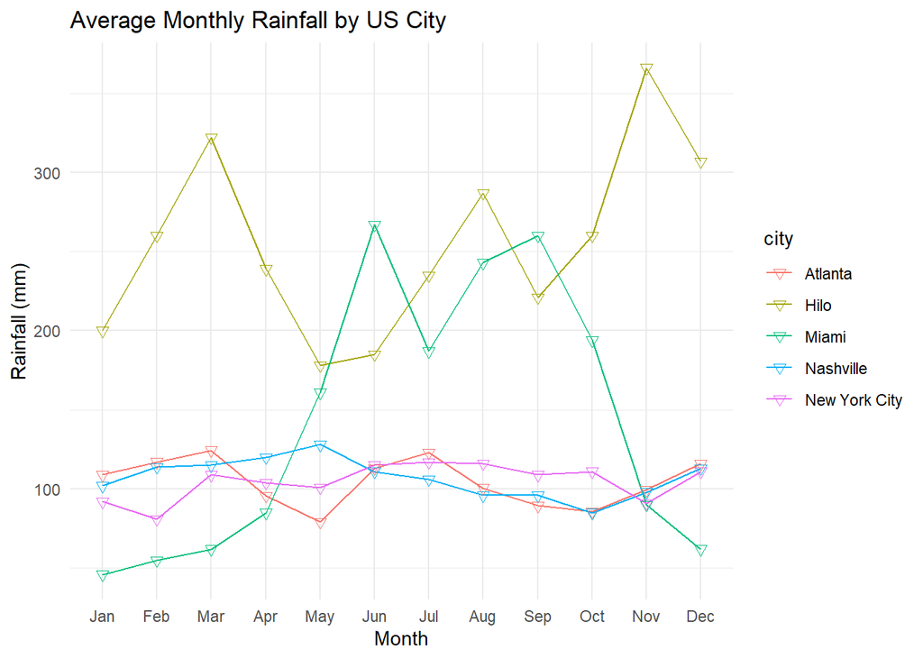

```r
#time plot

ggplot(us_rain_top_5, aes(x = month, y = rainfall_mm, group = city, color = city)) +
  geom_line() +
  geom_point(shape = 6, size = 2) +
  theme_minimal() +
  labs(title = "Average Monthly Rainfall by US City",
       x = "Month",
       y = "Rainfall (mm)")
```

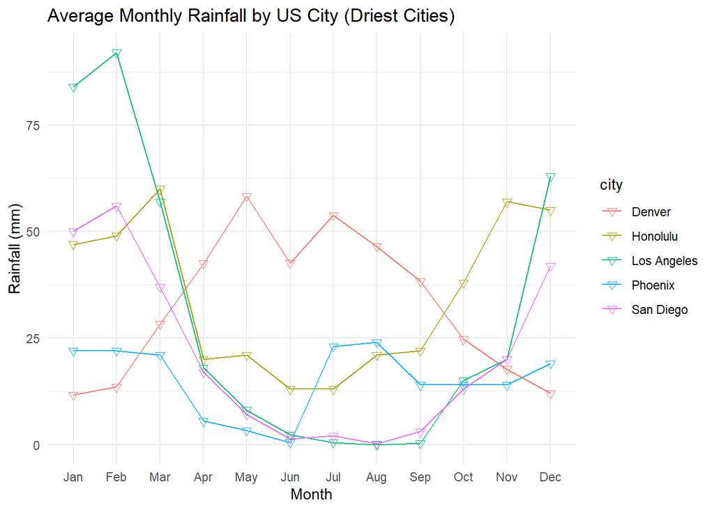

```r
#NY, Nashville, and Atlanta all have relatively steady precipitation throughout the year
#According to this data set, NYC is rainier than Portland and Seattle

#bottom five

us_rain <- rainfall_cleaned_numeric |>
  filter(country == "United States") |>
  arrange(yearly)

us_rain_bottom_5 <- us_rain |>
  filter(country == "United States") |>
  filter(city %in% c("Phoenix", "San Diego", "Los Angeles", "Denver", "Honolulu")) |>
  arrange(desc(yearly))

ggplot(us_rain_bottom_5, aes(x = month, y = rainfall_mm, group = city, color = city)) +
  geom_line() +
  geom_point(shape = 6, size = 2) +
  theme_minimal() +
  labs(title = "Average Monthly Rainfall by US City (Driest Cities)",
       x = "Month",
       y = "Rainfall (mm)")
```

```r
#With the exception of Denver, many of these lines have a U shape, indicating higher rainfall in winter months

#let's look at average rainfall by city

us_rain_avg <- rainfall_cleaned_numeric |>
  filter(country == "United States") |>
  group_by(city) |>
  summarize(monthly_avg = round(mean(rainfall_mm),2))


#this table showcases the wide range of avg. monthly rainfalls in the U.S. 15.19 - 255 mm

us_rain_avg |>
  gt() |>
  cols_label(
    city = "City",
    monthly_avg = "Average Monthly Rainfall"
  ) |>
  tab_header(title = "Average Monthly Rainfall in 21 U.S. Cities")
```

Average Monthly Rainfall in 21 U.S. Cities

| City | Average Monthly Rainfall |
| --- | --- |
| Anchorage | 34.78 |
| Atlanta | 104.38 |
| Austin | 76.72 |
| Chicago | 86.50 |
| Cincinnati | 89.77 |
| Columbus (Ohio) | 88.08 |
| Dallas | 81.10 |
| Denver | 32.49 |
| Des Moines | 75.81 |
| Detroit | 72.75 |
| Hilo | 255.00 |
| Honolulu | 34.67 |
| Los Angeles | 30.02 |
| Miami | 142.67 |
| Nashville | 107.00 |
| New York City | 104.75 |
| Phoenix | 15.19 |
| Portland | 78.17 |
| San Diego | 20.72 |
| San Francisco | 41.72 |
| Seattle | 78.72 |

## Football stats

```r
#Let's start by breaking up first name and last name

fg_names <- field_goal |>
    separate(col = Name, into = c("last_name", "first_name"), sep = ",")

#Pivot longer -- get rid of the percentage (we can calculate that if we need it)
#and  turn the columns into field goal type, made, and attempted
#this is a hard data set to pivot longer because many of the stats are unrelated
#(we don't want extra points mixed in with field goals or total field goals mixed in
#with field goal length + number made)

#there's also the question of whether we need the data not being pivoted.
#Besides identifiers, like name and team, every statistic except extra points
#can easily be derived from the pivoted data

fg_keep <- fg_names |>
  select(Player.Id:FG.Percentage, FGs.Made.20.29.Yards, FGs.Attempted.20.29.Yards, FGs.Made.30.39.Yards, FGs.Attempted.30.39.Yards, FGs.Made.40.49.Yards, FGs.Attempted.40.49.Yards, FGs.Made.50..Yards, FGs.Attempted.50..Yards, Extra.Points.Attempted, Extra.Points.Made, Extra.Points.Blocked)

fg_keep2 <- fg_keep |>
  mutate(across(contains(c("Yards", "Extra.Points")), as.numeric))

fg_long <- fg_keep2 |>
    pivot_longer(
        cols = contains("Yards"),
        names_to = c(".value", "field_goal_type"),
        names_pattern = "FGs\\.(Made|Attempted)\\.(.*)"
    )

#make this more readable
fg_cleaned <- fg_long |>
  mutate(field_goal_type = case_when(
  field_goal_type == "20.29.Yards" ~ "20-29 yards",
  field_goal_type == "30.39.Yards" ~ "30-39 yards",
  field_goal_type == "40.49.Yards" ~"40-49 yards",
  field_goal_type == "50..Yards" ~ "50 yards")
)

#clean up the names

fg_renamed <- fg_cleaned |> rename_with(tolower)

#replace period with underscore
colnames(fg_renamed) <- gsub(pattern = "\\.", replacement = "_", x = colnames(fg_renamed))

#move first name and last name so they're in the right order

fg_renamed <- fg_renamed |> relocate(last_name, .after = first_name)
```

### Analysis

I said I would look at cumulative player stats ratios (these are already included in the data set), and how the relationship of certain stats (such as player height and weight) relate to career length (these are excluded from the data set).

Instead, let’s look at how likely players are in general to make a field goal based on distance (total # of field goals / total attempted, grouped by type) and visualize it in a table.

Then, we’ll look at the top 5 teams in terms of field goals and field goal percentage.

```r
fg_likelihood <- fg_renamed |>
  mutate(across(c(made, attempted), as.numeric)) |>
  group_by(field_goal_type) |>
  summarize(
    made = sum(made, na.rm = TRUE),
    attempted = sum(attempted, na.rm = TRUE)
  )

fg_likelihood <- fg_likelihood |>
  mutate(percentage_made = round(made / attempted, 2))

#make a table
#Unsurprisingly, the farther a kicker is from the goal posts, the lower the percentage

fg_likelihood |>
  select(field_goal_type, percentage_made) |>
  gt() |>
  cols_label(
    field_goal_type = "Distance",
    percentage_made = "Percentage Made (%)"
  ) |>
  tab_header(title = "Percentage of Field Goals Made by Distance")
```

Percentage of Field Goals Made by Distance

| Distance | Percentage Made (%) |
| --- | --- |
| 20-29 yards | 0.95 |
| 30-39 yards | 0.87 |
| 40-49 yards | 0.72 |
| 50 yards | 0.56 |

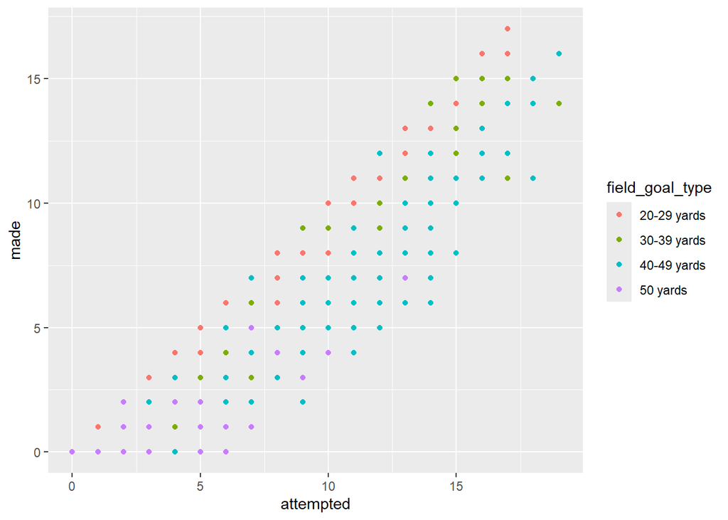

```r
ggplot(data = fg_renamed, aes(x = attempted, y = made, color = field_goal_type)) + geom_point()
```

```r
#dot plot visualizing total games played and number of field goals


#there are some baseball teams in here and defunct teams with 0 FGs,
#so let's filter those out too, and then go with the top 5 teams.

by_team <- fg_renamed |> group_by(team) |>
  mutate(across(c(made, attempted), as.numeric)) |>
  summarize(
    made = sum(made, na.rm = TRUE),
    attempted = sum(attempted, na.rm = TRUE)
  ) |>
  filter(attempted != 0) |>
  arrange(desc(made))


by_team |>
   slice(1:5) |>
  select(team, made) |>
  gt() |>
  cols_label(
    team = "NFL Team",
    made = "Total Field Goals Made"
  ) |>
  tab_header(title = "Top 5 Teams for Field Goals")
```

Top 5 Teams for Field Goals

| NFL Team | Total Field Goals Made |
| --- | --- |
| San Diego Chargers | 643 |
| New England Patriots | 626 |
| Atlanta Falcons | 625 |
| Denver Broncos | 625 |
| Buffalo Bills | 596 |

```r
#The San Diego Chargers have made the most field goals over the years, but these numbers
#are pretty close

#Let's look at percentage of field goals made


fg_percent <- by_team |>
  mutate(percentage = round(made / attempted, 2)) |>
  arrange(desc(percentage))


#in a table
fg_percent |>
   slice(1:5) |>
  gt() |>
  cols_label(
    team = "NFL Team",
    made = "Made",
    attempted = "Attempted",
    percentage = "% Made"
  ) |>
  tab_header(title = "NFL Teams With Highest Field Goal Success Rate")
```

NFL Teams With Highest Field Goal Success Rate

| NFL Team | Made | Attempted | % Made |
| --- | --- | --- | --- |
| Baltimore Ravens | 179 | 206 | 0.87 |
| Indianapolis Colts | 474 | 548 | 0.86 |
| Tennessee Oilers | 60 | 71 | 0.85 |
| Houston Texans | 170 | 203 | 0.84 |
| New England Patriots | 626 | 755 | 0.83 |

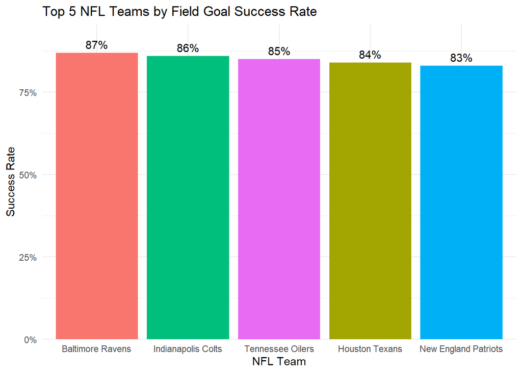

```r
#Theere's a wide range of attempts/FGs made represented here (possibly due to the age
#of the teams)
#The Baltimore Ravens have the highest percentage, but only 179 field goals made out of 206
#The Pats, on the other hand, rank fifth and have ade 626 out of 755

#a slightly more visually overwhelming presentation of the above info
fg_percent |>
  slice(1:5) |>
  ggplot(aes(x = reorder(team, -percentage), y = percentage, fill = team)) +
  geom_col(show.legend = FALSE) +
  geom_text(aes(label = scales::percent(percentage)), vjust = -0.5) +
  scale_y_continuous(labels = scales::percent, expand = expansion(mult = c(0, 0.1))) +
  labs(
    title = "Top 5 NFL Teams by Field Goal Success Rate",
    x = "NFL Team",
    y = "Success Rate"
  ) +
  theme_minimal()
```

Google Gemini. (2026). Gemini 3 Flash [Large language model].  
https://gemini.google.com. Accessed March 5, 2026.